# Skupljanje podataka za EW-NBS

#### Altman Z-score 2

```
Ignoring unknown parameters: positionRemoved 126 rows containing non-finite values (stat_density).D not labeled 0/1, assuming 1 = 0 and 2 = 1!
```

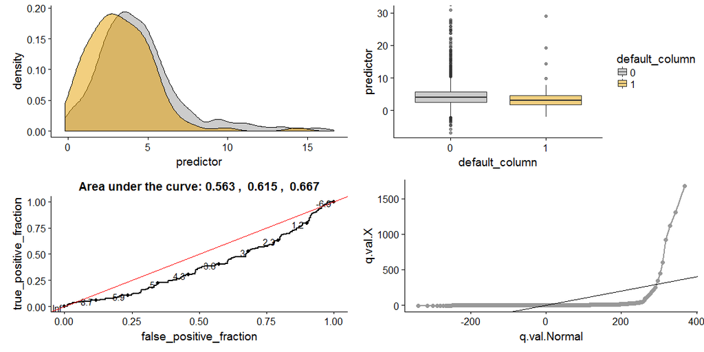

```r
#definisem funkciju za plotovanje
ploting(lrge.training,41,7)
```

#### Altman Z-score 3

```
Ignoring unknown parameters: positionRemoved 126 rows containing non-finite values (stat_density).D not labeled 0/1, assuming 1 = 0 and 2 = 1!
```

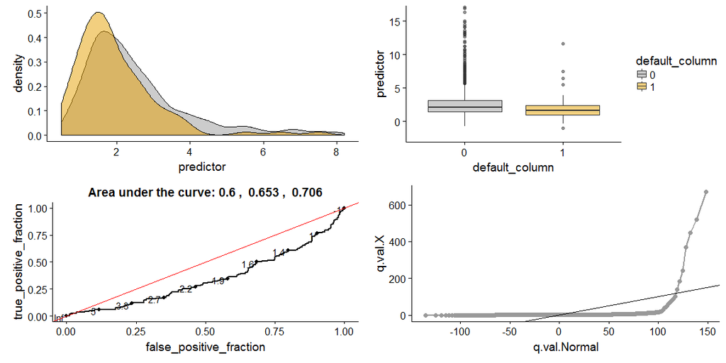

```r
#definisem funkciju za plotovanje
ploting(lrge.training,42,7)
```

#### Udeo u kapitalu banke

```
Ignoring unknown parameters: positionRemoved 126 rows containing non-finite values (stat_density).D not labeled 0/1, assuming 1 = 0 and 2 = 1!
```

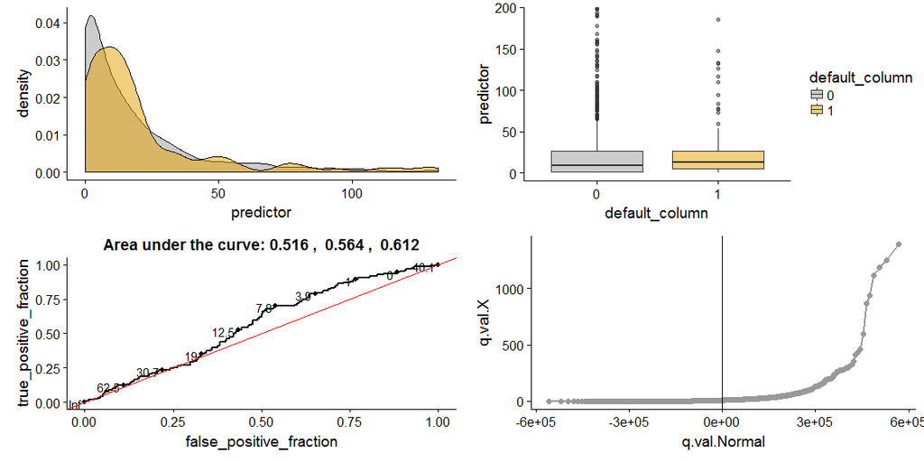

```r
#definisem funkciju za plotovanje
ploting(lrge.training,43,7)
```

- Radna hipoteza-zadovoljena je, veci udeo losiji su u proseku
- Diskriminativnost - za vece vrednosti da
- autlajeri - naravno ima ih
- normalnost - jook…

### Korelaciona matrica

Kao dodatni kriterijum selekcije uzimamo i korelacionu matricu. Vodicemo se pre svega diskriminativnom moci koju posmatramo prema AUROC vrednosti kao prvim kriterijumom pri izboru izmedju dve varijable sa velikim stepenom korelacije.  
U tabeli 5. ispod vidimo da najvecu diskriminacionu moc poseduje varijabla T14 odmah iza koje je ALtman 1.

```r
#proracun
cor=cor(lrge.training.continualne[,-1], use = "complete.obs")
#dodajemo AUROC kao dodatnu kolonu pored varijable
corr_summary<-function (predictor){
  response=factor(lrge.training.continualne[[1]])
suppressMessages(auc(response, as.numeric(predictor)))
}
auc_sumarno<-sapply(lrge.training.continualne[,-1], corr_summary)
kor_diskr<-(cbind(auc_sumarno,cor))
formatRound(
            datatable(
                      kor_diskr,caption = "Tabela 5.:Sumarni prikaz",
                      filter = 'none'
                      ),
            columns = colnames(kor_diskr)
           )
```

|  | auc_sumarno | udeo_ispravke.x | Broj_zaposlenih | Rigorozni_racio_redukovane_(monetarne)_likvidnosti | Racio_novcane_likvidnosti_(Cash_ratio) | Opsti_racio_likvidnosti | Stepen_zaduzenosti | Racio_pokrica_kamata_zaradom_pre_kamata_i_poreza_(Interest_Coverage_Ratio) | Racio_pokrica_obrtne_imovine | Racio_obrta_potrazivanja_od_kupaca | Racio_obrta_poslovne_imovine | Gotovinski_ciklus_1 | Vreme_vezivanja_zaliha | Vreme_kreditiranja_kupaca | Vreme_naplate_potrazivanja | Vreme_placanja_dobavljacima | Asset_turnover | Rast_EBITDA | Stopa_prinosa_na_sopstveni_kapital_pre_oporezivanja | Stopa_prinosa_na_ukupna_sredstva_pre_oporezivanja | Basic_Earnings_Power_Ratio | Rast_prihoda_od_prodaje | Pokrice_neto_kamata | Cena_tudjih_izvora_sredstava | T11 | T12 | T13 | T14 | T15 | … |
| --- | --- | --- | --- | --- | --- | --- | --- | --- | --- | --- | --- | --- | --- | --- | --- | --- | --- | --- | --- | --- | --- | --- | --- | --- | --- | --- | --- | --- | --- | --- |
| udeo_ispravke.x | 0.558318251027033 | 1 | -0.01265780967699 | 0.0149946573411412 | 0.0410555460444579 | -0.0120276563336924 | -0.0050875993203291 | -0.00720837822486583 | 0.00280217218713928 | -0.00970042814393174 | -0.0036516492794408 | -0.00732311259899085 | 0.319997647152063 | -0.00541398938319834 | -0.00632237825039955 | 0.30663817053765 | -0.00629230556283639 | 0.00516649825624543 | -0.000314545765240333 | -0.000362637600627903 | -0.000150821378260932 | -0.00077204240409997 | -0.00315674650905416 | -0.0052532213728144 | 0.0340980724368797 | 0.0157286961703339 | -0.0265670335574351 | -0.00740870546748468 | 0.00228283794829318 | … |
| Broj_zaposlenih | 0.523230342727455 | -0.01265780967699 | 1 | -0.0256636729954989 | 0.0260190116541594 | 0.0208624852832146 | -0.0264929372899565 | 0.0790518191958419 | -0.125689058915077 | 0.0290172411231508 | -0.115705157035518 | -0.0561450991249872 | -0.0106018535075976 | -0.0344036865681705 | -0.0322616935510176 | -0.0148836275135338 | -0.11710908055402 | -0.0289844840518477 | -0.0340181150981698 | -0.0981497643074875 | -0.112174346314848 | -0.0170655612727118 | 0.0233729029207037 | -0.0125371846598786 | -0.13812818082204 | -0.10764534874292 | -0.109961480199535 | 0.0900563035926521 | -0.115020702351302 | … |
| Rigorozni_racio_redukovane_(monetarne)_likvidnosti | 0.584354066985646 | 0.0149946573411412 | -0.0256636729954989 | 1 | 0.331518694837143 | -0.04649192464577 | -0.0246508632677734 | 0.102838432713582 | 0.189152710757569 | -0.100186433021163 | 0.00297225752848989 | 0.0553672279069356 | 0.0142001028391302 | 0.0503911936118929 | 0.161808502787862 | 0.00977978793813776 | 0.0160789683850745 | 0.0253026525407294 | 0.0233780400523678 | 0.207339347225852 | 0.187737466493702 | -0.00304407502877577 | -0.0161617950833029 | -0.0548716031479472 | 0.553032275943006 | 0.349698076703932 | 0.122413054055592 | 0.479179390660302 | 0.0047509473612552 | … |
| Racio_novcane_likvidnosti_(Cash_ratio) | 0.679541963412931 | 0.0410555460444579 | 0.0260190116541594 | 0.331518694837143 | 1 | 0.108489637117001 | -0.0318227742529247 | 0.181275641284266 | 0.0638829345535622 | 0.0301680639987275 | -0.0378894117660426 | 0.0528504824446557 | 0.0108853795860698 | -0.0381075887433261 | -0.0345621241691853 | 0.00173344946589819 | -0.034550435720876 | 0.00961476205958604 | 0.00170571965064833 | 0.160086104879327 | 0.13774646489527 | -0.0142474266277273 | 0.00527463830921019 | -0.117656840465269 | 0.296841256383697 | 0.220864765398544 | 0.106372245037114 | 0.229134877505492 | -0.0515994199468091 | … |
| Opsti_racio_likvidnosti | 0.535594242868224 | -0.0120276563336924 | 0.0208624852832146 | -0.04649192464577 | 0.108489637117001 | 1 | -0.00578765787779835 | -4.10670179104759e-05 | 0.020303651660232 | 0.258076034974607 | -0.0979424329696699 | 0.0672040043048421 | 0.0540244759056184 | -0.0538075254113542 | 0.146235740018368 | -0.00601300419740507 | -0.104112709601239 | -0.0189727157612923 | -0.0452367325528177 | -0.00336414201515437 | -0.00619687988993467 | -0.00913353393856206 | 0.0208292638771808 | 0.0644080667302957 | 0.0600547820375312 | 0.0281903498822703 | -0.0296229850273617 | 0.0497691689905522 | -0.0832162142958118 | … |
| Stepen_zaduzenosti | 0.659164205452015 | -0.0050875993203291 | -0.0264929372899565 | -0.0246508632677734 | -0.0318227742529247 | -0.00578765787779835 | 1 | -0.0146177167364731 | 0.000939581375809946 | -0.00341986897517547 | 0.0677602380914216 | -0.00986091631498308 | -0.00346797411198831 | -0.0126602097827645 | -0.00422647617212479 | -0.00384420300444112 | 0.0580399853476182 | 0.00188316472095644 | 0.761460172868101 | -0.0362837988107967 | -0.0111549258334342 | 0.00615297220194546 | -0.000830308831991753 | 0.066205385308749 | -0.0390545033747955 | -0.0699082541932108 | -0.0527580729602804 | -0.0492641939511959 | 0.0627622036387019 | … |
| Racio_pokrica_kamata_zaradom_pre_kamata_i_poreza_(Interest_Coverage_Ratio) | 0.583489681050657 | -0.00720837822486583 | 0.0790518191958419 | 0.102838432713582 | 0.181275641284266 | -4.10670179104759e-05 | -0.0146177167364731 | 1 | 0.0910596418333287 | -0.0021540094323285 | -0.0150083738884445 | 0.0489947298023483 | -0.00339762656849217 | -0.0501659022882455 | -0.0100950180191096 | -0.00482531821812251 | -0.0169739563311599 | 0.0997631600787213 | 0.0701792859214094 | 0.338989652126342 | 0.340833859241419 | -0.00569507643865982 | -0.0117950130636473 | -0.048071165461625 | 0.100501601768338 | 0.154845509490781 | 0.197555981831537 | 0.0434272471471028 | -0.0202944954937982 | … |
| Racio_pokrica_obrtne_imovine | 0.648618173460887 | 0.00280217218713928 | -0.125689058915077 | 0.189152710757569 | 0.0638829345535622 | 0.020303651660232 | 0.000939581375809946 | 0.0910596418333287 | 1 | -0.0127535656614613 | 0.0937728120060096 | 0.0471029462050291 | 0.00750678609454709 | -0.354334137489194 | 0.157512427430184 | -0.0311179628223044 | 0.0965515303767887 | 0.0131372550312817 | 0.0364786171257516 | 0.132196898366461 | 0.134981042162727 | -0.0051325016365862 | -0.00389341547034872 | 0.0111825381825815 | 0.299098906199223 | 0.161071545614942 | 0.102069464851259 | 0.0398117839401294 | 0.0940368460039836 | … |
| Racio_obrta_potrazivanja_od_kupaca | 0.546966975001911 | -0.00970042814393174 | 0.0290172411231508 | -0.100186433021163 | 0.0301680639987275 | 0.258076034974607 | -0.00341986897517547 | -0.0021540094323285 | -0.0127535656614613 | 1 | 0.553452397211508 | 0.047475623466582 | -0.0150735576582385 | -0.101846169016492 | -0.0580081439826379 | -0.0174372065487654 | 0.488213851695257 | 0.0595045664045794 | 0.0206984010411528 | 0.254522435398841 | 0.254985434209321 | 0.0275351257197155 | 0.00395233416553826 | -0.0555811355096324 | -0.121971104394292 | 0.128815976376131 | 0.283840317904629 | -0.0134368010012872 | 0.408055031425045 | … |
| Racio_obrta_poslovne_imovine | 0.560297377876309 | -0.0036516492794408 | -0.115705157035518 | 0.00297225752848989 | -0.0378894117660426 | -0.0979424329696699 | 0.0677602380914216 | -0.0150083738884445 | 0.0937728120060096 | 0.553452397211508 | 1 | 0.0750179915893599 | -0.0153131156821081 | -0.159365239201371 | -0.120531078773733 | -0.0010340464712422 | 0.981210485495356 | 0.0780929626914574 | 0.110527152260348 | 0.37528432359573 | 0.376575805161647 | 0.101309370814761 | 0.00114548585614896 | -0.138298456545577 | -0.0117883425534111 | 0.200129717458949 | 0.370324349983843 | -0.14796015219042 | 0.925010880916675 | … |

[output cut: 23 more lines]

Ovde kreiram funkciju koja ce da filtrira varijable po kriterijumu korelacije. Naime, po ugledu na [^4] kao kriterijum granice koeficijenta korelacije preko koje ne bismo smeli prelaziti uzecemo vrednost od 0.5 koji ce u sprezi sa AUROC vrednosti selektirati jednu od dve varijable. Konacan izbor varijabli se vidi u korelacionoj tabeli ispod.

```r
#assuming that table is n x (n+1) matrix where first column is AUROC value and the rest n x n is correlation matrix
corr_ellimination<-function(table1, ro=0.5){
  table=table1
  AUROC<-table[,1]
  table<-table[order(table[,1],decreasing = T),][,-1]
  table.temp=as.data.frame(table)
  for(i in 1:ncol(table)){#kolona
    for(j in 1:nrow(table)){#red
      #browser()
      if(abs(table[i,j])>ro & abs(table[i,j])<1){
        row.name=rownames(table)[i]
        if(sum(row.name==colnames(table.temp))==0) next
        col.name=colnames(table)[j]
        table.temp=table.temp[,col.name!=colnames(table.temp)]
        table.temp=table.temp[col.name!=row.names(table.temp),]
      }
    }
  }

  AUROC=AUROC[rownames(table.temp)]
  table.temp=cbind(table.temp,AUROC)
  table.temp<-table.temp[AUROC>0.55,]
  table.temp[order(rownames(table.temp)),order(colnames(table.temp))]
}
clean_cor<-corr_ellimination(kor_diskr)
knitr::kable(clean_cor, caption = "Tabela 6. skracena korelaciona tabela koja sadrzi varijable nad kojima ce se vrsiti dalja analiza")
```

|  | AUROC | Broj_zaposlenih | Cena_tudjih_izvora_sredstava | Gotovinski_ciklus_1 | Opsti_racio_likvidnosti | Pokrice_neto_kamata | Racio_novcane_likvidnosti_(Cash_ratio) | Racio_obrta_poslovne_imovine | Racio_pokrica_kamata_zaradom_pre_kamata_i_poreza_(Interest_Coverage_Ratio) | Racio_pokrica_obrtne_imovine | Rast_EBITDA | Rast_prihoda_od_prodaje | Stepen_zaduzenosti | Stopa_prinosa_na_ukupna_sredstva_pre_oporezivanja | T11 | T14 | T21 | udeo_ispravke.x | udeo_u_kapitalu | Vreme_kreditiranja_kupaca | Vreme_naplate_potrazivanja | Vreme_placanja_dobavljacima |
| --- | --- | --- | --- | --- | --- | --- | --- | --- | --- | --- | --- | --- | --- | --- | --- | --- | --- | --- | --- | --- | --- | --- |
| Cena_tudjih_izvora_sredstava | 0.6262839 | -0.0125372 | 1.0000000 | 0.0273657 | 0.0644081 | 0.0403725 | -0.1176568 | -0.1382985 | -0.0480712 | 0.0111825 | -0.0519739 | -0.0327648 | 0.0662054 | -0.2353706 | -0.0749077 | -0.0285439 | 0.0454153 | -0.0052532 | 0.0662291 | -0.0335581 | -0.0016848 | -0.0357971 |
| Gotovinski_ciklus_1 | 0.6218159 | -0.0561451 | 0.0273657 | 1.0000000 | 0.0672040 | 0.0787251 | 0.0528505 | 0.0750180 | 0.0489947 | 0.0471029 | 0.0252469 | -0.0161843 | -0.0098609 | 0.1167082 | 0.2990811 | 0.0448762 | -0.1970456 | -0.0073231 | 0.0663733 | -0.1682054 | -0.3692179 | -0.1085560 |
| Racio_novcane_likvidnosti_(Cash_ratio) | 0.6795420 | 0.0260190 | -0.1176568 | 0.0528505 | 0.1084896 | 0.0052746 | 1.0000000 | -0.0378894 | 0.1812756 | 0.0638829 | 0.0096148 | -0.0142474 | -0.0318228 | 0.1600861 | 0.2968413 | 0.2291349 | 0.0903443 | 0.0410555 | -0.0719486 | -0.0381076 | -0.0345621 | 0.0017334 |
| Racio_obrta_poslovne_imovine | 0.5602974 | -0.1157052 | -0.1382985 | 0.0750180 | -0.0979424 | 0.0011455 | -0.0378894 | 1.0000000 | -0.0150084 | 0.0937728 | 0.0780930 | 0.1013094 | 0.0677602 | 0.3752843 | -0.0117883 | -0.1479602 | 0.1968406 | -0.0036516 | -0.0939419 | -0.1593652 | -0.1205311 | -0.0010340 |
| Racio_pokrica_kamata_zaradom_pre_kamata_i_poreza_(Interest_Coverage_Ratio) | 0.5834897 | 0.0790518 | -0.0480712 | 0.0489947 | -0.0000411 | -0.0117950 | 0.1812756 | -0.0150084 | 1.0000000 | 0.0910596 | 0.0997632 | -0.0056951 | -0.0146177 | 0.3389897 | 0.1005016 | 0.0434272 | 0.0122804 | -0.0072084 | 0.0581242 | -0.0501659 | -0.0100950 | -0.0048253 |
| Racio_pokrica_obrtne_imovine | 0.6486182 | -0.1256891 | 0.0111825 | 0.0471029 | 0.0203037 | -0.0038934 | 0.0638829 | 0.0937728 | 0.0910596 | 1.0000000 | 0.0131373 | -0.0051325 | 0.0009396 | 0.1321969 | 0.2990989 | 0.0398118 | 0.2024268 | 0.0028022 | -0.0902430 | -0.3543341 | 0.1575124 | -0.0311180 |
| Rast_EBITDA | 0.5621120 | -0.0289845 | -0.0519739 | 0.0252469 | -0.0189727 | 0.0015314 | 0.0096148 | 0.0780930 | 0.0997632 | 0.0131373 | 1.0000000 | 0.3222574 | 0.0018832 | 0.2226443 | 0.0645130 | 0.0072692 | 0.0547935 | 0.0051665 | -0.0115522 | -0.0000271 | 0.0006407 | -0.0011215 |
| Stepen_zaduzenosti | 0.6591642 | -0.0264929 | 0.0662054 | -0.0098609 | -0.0057877 | -0.0008303 | -0.0318228 | 0.0677602 | -0.0146177 | 0.0009396 | 0.0018832 | 0.0061530 | 1.0000000 | -0.0362838 | -0.0390545 | -0.0492642 | 0.0675696 | -0.0050876 | -0.0005336 | -0.0126602 | -0.0042265 | -0.0038442 |
| Stopa_prinosa_na_ukupna_sredstva_pre_oporezivanja | 0.6765276 | -0.0981498 | -0.2353706 | 0.1167082 | -0.0033641 | -0.0431354 | 0.1600861 | 0.3752843 | 0.3389897 | 0.1321969 | 0.2226443 | 0.0331939 | -0.0362838 | 1.0000000 | 0.3341562 | 0.0799726 | 0.2051042 | -0.0003626 | -0.0804912 | -0.1067846 | -0.0614302 | 0.0707684 |
| T11 | 0.5873840 | -0.1381282 | -0.0749077 | 0.2990811 | 0.0600548 | -0.0050114 | 0.2968413 | -0.0117883 | 0.1005016 | 0.2990989 | 0.0645130 | -0.0097363 | -0.0390545 | 0.3341562 | 1.0000000 | 0.1894413 | 0.3826966 | 0.0340981 | -0.0668721 | 0.0096144 | 0.1189572 | 0.0453227 |
| T14 | 0.6929879 | 0.0900563 | -0.0285439 | 0.0448762 | 0.0497692 | 0.0047271 | 0.2291349 | -0.1479602 | 0.0434272 | 0.0398118 | 0.0072692 | -0.0224464 | -0.0492642 | 0.0799726 | 0.1894413 | 1.0000000 | -0.0920563 | -0.0074087 | -0.0867646 | 0.0023993 | 0.0227013 | -0.0125882 |
| udeo_ispravke.x | 0.5583183 | -0.0126578 | -0.0052532 | -0.0073231 | -0.0120277 | -0.0031567 | 0.0410555 | -0.0036516 | -0.0072084 | 0.0028022 | 0.0051665 | -0.0007720 | -0.0050876 | -0.0003626 | 0.0340981 | -0.0074087 | 0.0309182 | 1.0000000 | -0.0242572 | -0.0054140 | -0.0063224 | 0.3066382 |
| udeo_u_kapitalu | 0.5639203 | 0.0666854 | 0.0662291 | 0.0663733 | -0.0053593 | 0.0059530 | -0.0719486 | -0.0939419 | 0.0581242 | -0.0902430 | -0.0115522 | -0.0061007 | -0.0005336 | -0.0804912 | -0.0668721 | -0.0867646 | -0.0767029 | -0.0242572 | 1.0000000 | 0.1328014 | -0.0054992 | -0.0140915 |
| Vreme_naplate_potrazivanja | 0.5796346 | -0.0322617 | -0.0016848 | -0.3692179 | 0.1462357 | -0.0032530 | -0.0345621 | -0.1205311 | -0.0100950 | 0.1575124 | 0.0006407 | -0.0080463 | -0.0042265 | -0.0614302 | 0.1189572 | 0.0227013 | 0.1629485 | -0.0063224 | -0.0054992 | 0.1709806 | 1.0000000 | 0.0574205 |
| Vreme_placanja_dobavljacima | 0.5891748 | -0.0148836 | -0.0357971 | -0.1085560 | -0.0060130 | -0.0628841 | 0.0017334 | -0.0010340 | -0.0048253 | -0.0311180 | -0.0011215 | -0.0034926 | -0.0038442 | 0.0707684 | 0.0453227 | -0.0125882 | 0.0831601 | 0.3066382 | -0.0140915 | 0.0485313 | 0.0574205 | 1.0000000 |

Da sumiramo, do sada smo kod kontinualnih, pregledali diskriminativnost. Generalno [^5] preporucuje da se odradi *univariate* logisticka pa njena diskriminativnost testira. Medjutim ovde smo pratili [^6] gde smo posmatrali diskriminativnost samih varijabli. Dalje, postoji par varijabli koje bismo mogli da transformisemo u kategoricke, sto je pozeljno.

Osim testiranja monotonosti hipoteze, negde se testira i postojanje linearne zavisnost izmedju logaritma empirijskih sansi i varijabli[^7] i istovremeno se transformisu varijable. [^8] prikazuju postupak transformacije ali i upozoravaju na opasnost od *data.mining*-a, [^9] i [^10] takodje primenjuju istovetan postupak. Mi cemo ovde koristiti postupak opisan u [^11] za par varijabli koje nisu pokazale monotonu zavisnost sa hipotezom, ukoliko nuzda natera, ali samo tada, transformisacemo sve kontinualne varijable. Za sada cemo ovaj postupak primeniti na varijablama *Pokriće neto kamata, Asset turnover*. Varijabla koju cemo pretvoriti u kategoricku je *Udeo u kapitalu banke*. Dinamicke varijable *Rast EBITDA i Racio obrta poslovne imovine* nemaju neku previse znacajnu diskriminativnu moc da bi se opravdalo skracenje citave serije uzorka, tako da ce se tretirati kao da su otpale u *univariate analysis* usled velikog broja nedostajucih vrednosti. Napravicemo jedan izuzetak kada budemo primenili pravilo odstranjivanja varijabli usled nedostajucih vrednosti, a to je varijabla koja je na granici, *Cash_ratio* jer je pokazala veliku diskrimacionu moc. Diskriminacionu moc gledamo po znacajnosti intervala poverenja od 95%, koji se kod funkcije u R-u racuna bootstrapovanjem. Generalno, vrednosti AUROC-a u vecim uzorcima koje imaju vrednosti vece od 55 se mogu smatrati znacajnim.

Pa hajde da krenemo sa gore navedenim. Takodje, videh da je mozda broj zaposlenih bilo potrebno rtacunati prema aktivi kao racio, ali to mi ranije nije palo na pamet, mada ne mislim da bi imalo znacajnih promena, eventualno, varijabla koja bi imala smisla je procentualna promena ove varijable, što bi, opet, zahtevalo gubljenje prve godine observacija samo zbog nje, jer se druge dinamicke varijable nisu pokazale kao dovoljno diskriminativno znacajne.

Dodatno o dinamickim varijablama, u buducim vezbama, predlazem da se skroz izbace iz selekcije iz razloga sto nisu monotone, naime, buduci da ove varijable mogu uzimati kako negativne tako i pozitivne vrednosti. Primera radi, moguc je sledeci slucaj, recimo da imamo dva preduzeca $X^{[1]}$ i $X^{[2]}$, u roku od dve godine oni su ostvarili sledece vrednosti nekog racija koji je obrnuto povezan sa difoltom (veci racio-manji PD):
$$t:X_{t}^{[1]}=-0.5, X_{t}^{[2]}=0.7 \\ t+1:X_{t+1}^{[1]}=-0.9, X_{t+1}^{[2]}=0.9$$
Tako da ukoliko sada izracunamo rast ovog racija za oba preduzeca dobijamo:
$$R_{x^{[1]}}=\frac{X_{t+1}^{[1]}}{X_{t}^{[2]}}-1=80 \%\\ R_{x^{[2]}}=\frac{X_{t+1}^{[1]}}{X_{t}^{[2]}}-1=28\%$$

, sto bi znacilo da preduzece 1 ima bolji PD od preduzeca 2 po pocetnoj hipotezi, a to ne moze biti jer je pozicija preduzeca 1 od starta bila losija i jos se pogorsala u sledecih godinu dana. Ovo je glavni razlog zbog koga, verovatno, ovakve varijable nisu pokazale jaku diskriminativnu moc. Kada se odlucimo u buducnosti za proracun rasta kao potencijalnu varijablu, potrebno je da on pre svega bude racunat na monotonim varijablama, koje ne menjaju znak!

Nastavljamo:

### Tretman problematicnih varijabli

Ipak, ovde cemo se koncentrisati na par prethodno napomenutih varijabli.